# US Gun-Related Background Checks Analysis and Trends

- Introduction
- Data Wrangling
- Exploratory Data Analysis
- Conclusions

## Introduction

> This project will investigate and analyze a dataset of gun-related background checks from 1998 to 2017 for different types of gun background checks, such as concealed-carry permits, handgun purchases, and long gun purchases provided by the FBI's background check system. This dataset shares the number of each type of background check in a certain month for each of the 50 states.

> **In this project I will analyze the dataset by answering the following questions:**
> - Which states have the highest total gun-related background checks?
> - Which states have the highest gun-related background checks per capita?
> - What socioeconomic factors contribute to a state having a high gun-related background checks per capita?
> - What does the trend of gun-related background checks look like for the 5 states with the highest high gun-related backgrounds per capita?
> - Which of these states has shown the highest average percentage change in gun-related background checks over the time frame available in the dataset?
> - What do the overall trends look like for concealed-carry permits, handguns, and long guns?

```python
#Importing necessary packages to execute the analysis of the dataset
import pandas as pd
import numpy as np
import matplotlib.pyplot as plt
import seaborn as sns
%matplotlib inline
```

## Data Wrangling

### General Properties

```python
#Loading gun-related background check dataset and U.S. census data set
gun_data = pd.read_csv('gun_data.csv')
census = pd.read_csv('U.S. Census Data.csv')
```

```python
#Inspecting the first 5 rows of the gun dataset
gun_data.head(5)
```

|  | month | state | permit | permit_recheck | handgun | long_gun | other | multiple | admin | prepawn_handgun | ... | returned_other | rentals_handgun | rentals_long_gun | private_sale_handgun | private_sale_long_gun | private_sale_other | return_to_seller_handgun | return_to_seller_long_gun | return_to_seller_other | totals |
| --- | --- | --- | --- | --- | --- | --- | --- | --- | --- | --- | --- | --- | --- | --- | --- | --- | --- | --- | --- | --- | --- |
| 0 | 2017-09 | Alabama | 16717.0 | 0.0 | 5734.0 | 6320.0 | 221.0 | 317 | 0.0 | 15.0 | ... | 0.0 | 0.0 | 0.0 | 9.0 | 16.0 | 3.0 | 0.0 | 0.0 | 3.0 | 32019 |
| 1 | 2017-09 | Alaska | 209.0 | 2.0 | 2320.0 | 2930.0 | 219.0 | 160 | 0.0 | 5.0 | ... | 0.0 | 0.0 | 0.0 | 17.0 | 24.0 | 1.0 | 0.0 | 0.0 | 0.0 | 6303 |
| 2 | 2017-09 | Arizona | 5069.0 | 382.0 | 11063.0 | 7946.0 | 920.0 | 631 | 0.0 | 13.0 | ... | 0.0 | 0.0 | 0.0 | 38.0 | 12.0 | 2.0 | 0.0 | 0.0 | 0.0 | 28394 |
| 3 | 2017-09 | Arkansas | 2935.0 | 632.0 | 4347.0 | 6063.0 | 165.0 | 366 | 51.0 | 12.0 | ... | 0.0 | 0.0 | 0.0 | 13.0 | 23.0 | 0.0 | 0.0 | 2.0 | 1.0 | 17747 |
| 4 | 2017-09 | California | 57839.0 | 0.0 | 37165.0 | 24581.0 | 2984.0 | 0 | 0.0 | 0.0 | ... | 0.0 | 0.0 | 0.0 | 0.0 | 0.0 | 0.0 | 0.0 | 0.0 | 0.0 | 123506 |

5 rows × 27 columns

```python
#Inspecting the size of the gun dataset, the number of values in each column, and its data types
gun_data.info()
```

```
<class 'pandas.core.frame.DataFrame'>
RangeIndex: 12485 entries, 0 to 12484
Data columns (total 27 columns):
 #   Column                     Non-Null Count  Dtype
---  ------                     --------------  -----
 0   month                      12485 non-null  object
 1   state                      12485 non-null  object
 2   permit                     12461 non-null  float64
 3   permit_recheck             1100 non-null   float64
 4   handgun                    12465 non-null  float64
 5   long_gun                   12466 non-null  float64
 6   other                      5500 non-null   float64
 7   multiple                   12485 non-null  int64
 8   admin                      12462 non-null  float64
 9   prepawn_handgun            10542 non-null  float64
```

[output cut: 19 more lines]

**After inspecting the dataset, I discovered that several of the columns had null values. So in the cell below I fill these null values with 0 to show that there were no background checks of that type in that state for that month. I also noticed that the month column was listed as an object, so I changed this to datetime using pd.to_datetime() and then I confirmed these changes by checking .info() again.**

```python
gun_data.fillna(0,inplace=True)
gun_data['month'] = pd.to_datetime(gun_data['month'],errors='ignore')
gun_data.info()
```

```
<class 'pandas.core.frame.DataFrame'>
RangeIndex: 12485 entries, 0 to 12484
Data columns (total 27 columns):
 #   Column                     Non-Null Count  Dtype
---  ------                     --------------  -----
 0   month                      12485 non-null  datetime64[ns]
 1   state                      12485 non-null  object
 2   permit                     12485 non-null  float64
 3   permit_recheck             12485 non-null  float64
 4   handgun                    12485 non-null  float64
 5   long_gun                   12485 non-null  float64
 6   other                      12485 non-null  float64
 7   multiple                   12485 non-null  int64
 8   admin                      12485 non-null  float64
 9   prepawn_handgun            12485 non-null  float64
```

[output cut: 19 more lines]

```python
#Loading U.S census dataset
census = pd.read_csv('U.S. Census Data.csv')
```

```python
#Inspecting the first 5 rows of the gun dataset
census.head()
```

|  | Fact | Fact Note | Alabama | Alaska | Arizona | Arkansas | California | Colorado | Connecticut | Delaware | ... | South Dakota | Tennessee | Texas | Utah | Vermont | Virginia | Washington | West Virginia | Wisconsin | Wyoming |
| --- | --- | --- | --- | --- | --- | --- | --- | --- | --- | --- | --- | --- | --- | --- | --- | --- | --- | --- | --- | --- | --- |
| 0 | Population estimates, July 1, 2016, (V2016) | NaN | 4,863,300 | 741,894 | 6,931,071 | 2,988,248 | 39,250,017 | 5,540,545 | 3,576,452 | 952,065 | ... | 865454 | 6651194 | 27,862,596 | 3,051,217 | 624,594 | 8,411,808 | 7,288,000 | 1,831,102 | 5,778,708 | 585,501 |
| 1 | Population estimates base, April 1, 2010, (V2... | NaN | 4,780,131 | 710,249 | 6,392,301 | 2,916,025 | 37,254,522 | 5,029,324 | 3,574,114 | 897,936 | ... | 814195 | 6346298 | 25,146,100 | 2,763,888 | 625,741 | 8,001,041 | 6,724,545 | 1,853,011 | 5,687,289 | 563,767 |
| 2 | Population, percent change - April 1, 2010 (es... | NaN | 1.70% | 4.50% | 8.40% | 2.50% | 5.40% | 10.20% | 0.10% | 6.00% | ... | 0.063 | 0.048 | 10.80% | 10.40% | -0.20% | 5.10% | 8.40% | -1.20% | 1.60% | 3.90% |
| 3 | Population, Census, April 1, 2010 | NaN | 4,779,736 | 710,231 | 6,392,017 | 2,915,918 | 37,253,956 | 5,029,196 | 3,574,097 | 897,934 | ... | 814180 | 6346105 | 25,145,561 | 2,763,885 | 625,741 | 8,001,024 | 6,724,540 | 1,852,994 | 5,686,986 | 563,626 |
| 4 | Persons under 5 years, percent, July 1, 2016, ... | NaN | 6.00% | 7.30% | 6.30% | 6.40% | 6.30% | 6.10% | 5.20% | 5.80% | ... | 0.071 | 0.061 | 7.20% | 8.30% | 4.90% | 6.10% | 6.20% | 5.50% | 5.80% | 6.50% |

5 rows × 52 columns

```python
#Inspecting the size of the census dataset, the number of values in each column, and its data types
census.info()
```

```
<class 'pandas.core.frame.DataFrame'>
RangeIndex: 85 entries, 0 to 84
Data columns (total 52 columns):
 #   Column          Non-Null Count  Dtype
---  ------          --------------  -----
 0   Fact            80 non-null     object
 1   Fact Note       28 non-null     object
 2   Alabama         65 non-null     object
 3   Alaska          65 non-null     object
 4   Arizona         65 non-null     object
 5   Arkansas        65 non-null     object
 6   California      65 non-null     object
 7   Colorado        65 non-null     object
 8   Connecticut     65 non-null     object
 9   Delaware        65 non-null     object
```

[output cut: 44 more lines]

**I know right away that this dataset is going to need a lot of work. First I notice that there are some fields that can be dropped from the dataset and that some should also be renamed. I will also need to transpose the data, in order to have the states as rows instead of columns to match the gun dataset.**

```python
#Dropping Fact Note, and rows at the end of the data set that aren't needed for analysis, and removing the name of
#the fact column and setting it as the index
census.drop(['Fact Note'],axis=1,inplace=True)
census.drop(census.index[64:85],inplace=True)
census = census.rename(columns={'Fact':''})
census.set_index('',inplace=True)
```

```python
#Transposing the dataframe to have the states as the rows, renaming the index column as state, removing spaces
#and characters from the column names to make them easier to work with
c = census.T.reset_index()
c = c.rename(columns={'index':'state'})
c.columns = c.columns.str.strip().str.lower().str.replace(' ', '_').str.replace('(', '').str.replace(')', '').str.replace(',','').str.replace('+','').str.replace('-','_').str.replace("'",'')
```

**The datatypes will still need to be changed, in order to be more accurate, but this will be done separately, in order to to keep that code interfering with dataframes that will be created later on to investigate specific socioeconomic factors.**

## Exploratory Data Analysis

### Which states have the highest gun-related background check totals?

```python
#Selecting the columns that I want to analyze and grouping the by state and aggregating all totals across the
#different states in order to find the state with the highest gun background check total
gun_data_totals = gun_data[['month','state','totals']]
gun_data_agg = gun_data_totals.groupby(['state']).aggregate({'totals':'sum'})
gun_data_agg.sort_values('totals',ascending=False)
```

| state | totals |
| --- | --- |
| Kentucky | 29762434 |
| Texas | 19435186 |
| California | 19014063 |
| Illinois | 15471534 |
| Pennsylvania | 13133876 |
| Florida | 11695777 |
| Ohio | 8462744 |
| North Carolina | 7777689 |
| Indiana | 7737172 |
| Tennessee | 7311293 |
| Michigan | 7254279 |
| Georgia | 7209942 |
| Alabama | 6706079 |
| Missouri | 6549018 |
| Washington | 6384517 |
| Minnesota | 6279271 |
| Colorado | 6058482 |
| Virginia | 5878675 |
| Wisconsin | 5131725 |
| Louisiana | 4705057 |
| New York | 4643828 |
| Oklahoma | 4584454 |
| Arizona | 4425714 |
| Utah | 4338273 |
| South Carolina | 4014432 |
| Arkansas | 3752633 |
| Oregon | 3751061 |
| Mississippi | 3576312 |
| West Virginia | 3208889 |
| Connecticut | 3168126 |
| Kansas | 2624669 |
| Massachusetts | 2571321 |
| Iowa | 2297156 |
| New Mexico | 2076591 |
| Maryland | 2035652 |
| Idaho | 1968134 |
| Montana | 1884124 |
| Nevada | 1731797 |
| New Hampshire | 1583148 |
| Maine | 1257457 |
| South Dakota | 1215712 |
| New Jersey | 1145846 |
| Alaska | 1137643 |
| Nebraska | 1136209 |
| North Dakota | 947440 |
| Wyoming | 894306 |
| Delaware | 491369 |
| Vermont | 484447 |
| Rhode Island | 288870 |
| Hawaii | 197580 |
| Puerto Rico | 194464 |
| Virgin Islands | 15108 |
| Guam | 14997 |
| District of Columbia | 5601 |
| Mariana Islands | 462 |

```python
#Extracting the max from the above table
max = gun_data_agg['totals'].max()
gun_data_agg[gun_data_agg['totals'] == max]
```

| state | totals |
| --- | --- |
| Kentucky | 29762434 |

```python
#Finding the states with the highest gun background checks in a single month
gun_data_agg1 = gun_data_totals.groupby(['month','state']).aggregate({'totals':'sum'})
gun_data_agg1.sort_values('totals',ascending=False,inplace=True)
gun_data_agg1.head(5)
```

| month | state | totals |
| --- | --- | --- |
| 2014-03-01 | North Carolina | 541978 |
| 2017-09-01 | Kentucky | 398706 |
| 2017-03-01 | Kentucky | 397959 |
| 2016-12-01 | Kentucky | 397059 |
| 2017-08-01 | Kentucky | 394718 |

```python
#Extracting the max from the above table
max1 = gun_data_agg1['totals'].max()
gun_data_agg1[gun_data_agg1['totals'] == max1]
```

| month | state | totals |
| --- | --- | --- |
| 2014-03-01 | North Carolina | 541978 |

**In these tables, you can see that Kentucky has the highest number gun background checks followed by Texas, California, and Illinois, three of the biggest states in the US. Due to this, the totals data doesn't give the best analysis of the data, so I will find the state with the highest gun background checks per capita. I have also included which state has the highest number of gun backgrounds checks in a single month, and this was North Carolina followed by different months in Kentucky, as can be seen above. This result is, however, only for a certain time frame and is thus limited.**

### Which states have the highest gun-related background checks per capita?

```python
#Creating a dataframe with the latest population estimates per state
c_pop2016 = c.loc[:,['state','population_estimates_july_1_2016__v2016']]
c_pop2016['population_estimates_july_1_2016__v2016'] = c_pop2016['population_estimates_july_1_2016__v2016'].str.replace(',','')
c_pop2016['pop_7_1_2016'] = pd.to_numeric(c_pop2016['population_estimates_july_1_2016__v2016'],errors='ignore')
```

```python
#Confirming the dataframe is correct
c_pop2016.info()
```

```
<class 'pandas.core.frame.DataFrame'>
RangeIndex: 50 entries, 0 to 49
Data columns (total 3 columns):
 #   Column                                   Non-Null Count  Dtype
---  ------                                   --------------  -----
 0   state                                    50 non-null     object
 1   population_estimates_july_1_2016__v2016  50 non-null     object
 2   pop_7_1_2016                             50 non-null     int64
dtypes: int64(1), object(2)
memory usage: 1.3+ KB
```

```python
#Dropping old population column from the dataframe
c_pop2016.drop(['population_estimates_july_1_2016__v2016'],axis=1,inplace=True)
```

```python
#Creating the gun background checks per capita dataframe
gun_per_cap = gun_data_agg.merge(c_pop2016,on='state',how='inner')
gun_per_cap.rename(columns={'totals':'gun_background_checks'},inplace=True)
gun_per_cap.head(1)
```

|  | state | gun_background_checks | pop_7_1_2016 |
| --- | --- | --- | --- |
| 0 | Alabama | 6706079 | 4863300 |

```python
#Creating the per capita column
gun_per_cap['per_cap'] = gun_per_cap['gun_background_checks']/gun_per_cap['pop_7_1_2016']
```

```python
#Sorting the values by highest gun background checks per capita
gun_per_cap = gun_per_cap.sort_values('per_cap',ascending=False).reset_index(drop=True)
gun_per_cap = gun_per_cap.set_index('state')
gun_per_cap
```

| state | gun_background_checks | pop_7_1_2016 | per_cap |
| --- | --- | --- | --- |
| Kentucky | 29762434 | 4436974 | 6.707822 |
| Montana | 1884124 | 1042520 | 1.807279 |
| West Virginia | 3208889 | 1831102 | 1.752436 |
| Alaska | 1137643 | 741894 | 1.533431 |
| Wyoming | 894306 | 585501 | 1.527420 |
| Utah | 4338273 | 3051217 | 1.421817 |
| South Dakota | 1215712 | 865454 | 1.404710 |
| Alabama | 6706079 | 4863300 | 1.378915 |
| Arkansas | 3752633 | 2988248 | 1.255797 |
| North Dakota | 947440 | 757952 | 1.250000 |
| Illinois | 15471534 | 12801539 | 1.208568 |
| Mississippi | 3576312 | 2988726 | 1.196601 |
| New Hampshire | 1583148 | 1334795 | 1.186061 |
| Idaho | 1968134 | 1683140 | 1.169323 |
| Oklahoma | 4584454 | 3923561 | 1.168442 |
| Indiana | 7737172 | 6633053 | 1.166457 |
| Minnesota | 6279271 | 5519952 | 1.137559 |
| Tennessee | 7311293 | 6651194 | 1.099245 |
| Colorado | 6058482 | 5540545 | 1.093481 |
| Missouri | 6549018 | 6093000 | 1.074843 |
| Pennsylvania | 13133876 | 12784227 | 1.027350 |
| Louisiana | 4705057 | 4681666 | 1.004996 |
| New Mexico | 2076591 | 2081015 | 0.997874 |
| Maine | 1257457 | 1331479 | 0.944406 |
| Oregon | 3751061 | 4093465 | 0.916354 |
| Kansas | 2624669 | 2907289 | 0.902789 |
| Wisconsin | 5131725 | 5778708 | 0.888040 |
| Connecticut | 3168126 | 3576452 | 0.885829 |
| Washington | 6384517 | 7288000 | 0.876031 |
| South Carolina | 4014432 | 4961119 | 0.809179 |
| Vermont | 484447 | 624594 | 0.775619 |
| North Carolina | 7777689 | 10146788 | 0.766517 |
| Iowa | 2297156 | 3134693 | 0.732817 |
| Michigan | 7254279 | 9928300 | 0.730667 |
| Ohio | 8462744 | 11614373 | 0.728644 |
| Georgia | 7209942 | 10310371 | 0.699290 |
| Virginia | 5878675 | 8411808 | 0.698860 |
| Texas | 19435186 | 27862596 | 0.697537 |
| Arizona | 4425714 | 6931071 | 0.638532 |
| Nebraska | 1136209 | 1907116 | 0.595773 |
| Nevada | 1731797 | 2940058 | 0.589035 |
| Florida | 11695777 | 20612439 | 0.567414 |
| Delaware | 491369 | 952065 | 0.516109 |
| California | 19014063 | 39250017 | 0.484435 |
| Massachusetts | 2571321 | 6811779 | 0.377482 |
| Maryland | 2035652 | 6016447 | 0.338348 |
| Rhode Island | 288870 | 1056426 | 0.273441 |
| New York | 4643828 | 19745289 | 0.235187 |
| Hawaii | 197580 | 1428557 | 0.138307 |
| New Jersey | 1145846 | 8944469 | 0.128107 |

**As you can see, Kentucky also has the highest gun background checks per capita according to this data. New Jersey has the lowest according to the data. Now let's look more closely at the top 5 of these states.**

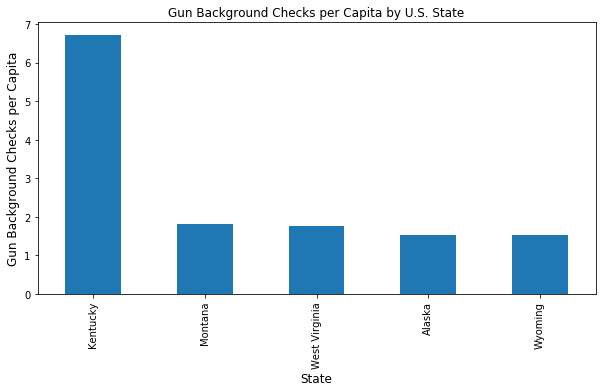

```python
#Visualizing the per capita data for the top 5 states
gun_per_cap['per_cap'].iloc[:5].plot.bar(figsize=(10,5))
plt.title('Gun Background Checks per Capita by U.S. State')
plt.xlabel('State',fontsize=12)
plt.ylabel('Gun Background Checks per Capita',fontsize=12);
```

**This bar chart shows the large difference between Kentucky and the rest of the top 5 states in gun background checks per capita.**

**Supporting articles:**

- https://www.courier-journal.com/story/news/investigations/2020/02/14/how-kentucky-counties-adopted-second-amendment-resolutions-oppose-gun-laws/4736639002/
- https://www.gunsandammo.com/editorial/best-states-for-gun-owners/369075

### What socioeconomic factors contribute to a state having a high gun-related backgrounds per capita?

```python
#Viewing the columns of the census dataframe to determine the socioeconomic factors to investigate
c.columns.sort_values()
```

```
Index(['all_firms_2012',
       'american_indian_and_alaska_native_alone_percent_july_1_2016__v2016',
       'asian_alone_percent_july_1_2016__v2016',
       'bachelors_degree_or_higher_percent_of_persons_age_25_years_2011_2015',
       'black_or_african_american_alone_percent_july_1_2016__v2016',
       'building_permits_2016', 'female_persons_percent__july_1_2016__v2016',
       'female_persons_percent_april_1_2010',
       'foreign_born_persons_percent_2011_2015',
       'high_school_graduate_or_higher_percent_of_persons_age_25_years_2011_2015',
       'hispanic_or_latino_percent_july_1_2016__v2016', 'households_2011_2015',
       'housing_units__july_1_2016__v2016', 'housing_units_april_1_2010',
       'in_civilian_labor_force_female_percent_of_population_age_16_years_2011_2015',
       'in_civilian_labor_force_total_percent_of_population_age_16_years_2011_2015',
       'land_area_in_square_miles_2010',
       'language_other_than_english_spoken_at_home_percent_of_persons_age_5_years_2011_2015',
       'living_in_same_house_1_year_ago_percent_of_persons_age_1_year_2011_2015',
       'mean_travel_time_to_work_minutes_workers_age_16_years_2011_2015',
       'median_gross_rent_2011_2015',
       'median_household_income_in_2015_dollars_2011_2015',
       'median_selected_monthly_owner_costs__with_a_mortgage_2011_2015',
       'median_selected_monthly_owner_costs__without_a_mortgage_2011_2015',
       'median_value_of_owner_occupied_housing_units_2011_2015',
       'men_owned_firms_2012', 'minority_owned_firms_2012',
       'native_hawaiian_and_other_pacific_islander_alone_percent_july_1_2016__v2016',
       'nonminority_owned_firms_2012', 'nonveteran_owned_firms_2012',
       'owner_occupied_housing_unit_rate_2011_2015',
       'per_capita_income_in_past_12_months_in_2015_dollars_2011_2015',
       'persons_65_years_and_over_percent__july_1_2016__v2016',
       'persons_65_years_and_over_percent_april_1_2010',
       'persons__without_health_insurance_under_age_65_years_percent',
       'persons_in_poverty_percent', 'persons_per_household_2011_2015',
       'persons_under_18_years_percent_april_1_2010',
       'persons_under_18_years_percent_july_1_2016__v2016',
       'persons_under_5_years_percent_april_1_2010',
       'persons_under_5_years_percent_july_1_2016__v2016',
       'population_census_april_1_2010',
       'population_estimates_base_april_1_2010__v2016',
       'population_estimates_july_1_2016__v2016',
       'population_per_square_mile_2010',
       'population_percent_change___april_1_2010_estimates_base_to_july_1_2016__v2016',
       'state', 'total_accommodation_and_food_services_sales_2012_$1000',
       'total_annual_payroll_2015_$1000', 'total_employer_establishments_2015',
       'total_employment_2015', 'total_employment_percent_change_2014_2015',
       'total_health_care_and_social_assistance_receipts/revenue_2012_$1000',
       'total_manufacturers_shipments_2012_$1000',
       'total_merchant_wholesaler_sales_2012_$1000',
       'total_nonemployer_establishments_2015',
       'total_retail_sales_2012_$1000', 'total_retail_sales_per_capita_2012',
       'two_or_more_races_percent_july_1_2016__v2016',
       'veteran_owned_firms_2012', 'veterans_2011_2015',
       'white_alone_not_hispanic_or_latino_percent_july_1_2016__v2016',
       'white_alone_percent_july_1_2016__v2016',
       'with_a_disability_under_age_65_years_percent_2011_2015',
       'women_owned_firms_2012'],
      dtype='object', name='')
```

**Education**

> **The first factor I will be investigating is education, which is often brought up in gun debates. I will use the percentage of person with a bachelor's degree or higher to analyze this.**

```python
#Creating the education dataframe
c_education = c.loc[:,['state','bachelors_degree_or_higher_percent_of_persons_age_25_years_2011_2015']]
c_education.set_index('state',inplace=True)
```

```python
#Some rows are formatted correctly, while others aren't. Here I'm selecting those rows that need to be corrected.
#I use .iloc() and numpy's np.r_() to select these rows, in order to reformat them and then change the data type
#to float
rows_to_change1 = c_education.iloc[np.r_[0:30,42:50]]
rows_to_change1.loc[:,'bachelors_degree_or_higher_percent_of_persons_age_25_years_2011_2015'] = rows_to_change1.loc[:,'bachelors_degree_or_higher_percent_of_persons_age_25_years_2011_2015'].str.rstrip('%').astype('float') / 100.0
```

```python
#Selecting the rows that don't need to be reformatted and then changing their datatype to float as well.
good_rows1 = c_education.loc['New Mexico':'Tennessee']
good_rows1 = good_rows1.astype(float)
```

```python
#Combining the two different sets of rows
new_rows1 = rows_to_change1.append(good_rows1).sort_values('state',)
```

```python
#Selecting the old rows and dropping them the dataframe
old_rows1 = c_education.iloc[:50]
c_education.drop(old_rows1.index,inplace=True)
```

```python
#Appending the corrected rows to the education dataframe
c_education = c_education.append(new_rows1)
```

```python
#Merging the gun background checks per capita and education dataframes by executing an inner join on state, in order
#to drop the states that are in the gun dataframe but not the census dataframe
gun_edu = gun_per_cap.merge(c_education,on='state',how='inner')
gun_edu = gun_edu.rename(columns={'bachelors_degree_or_higher_percent_of_persons_age_25_years_2011_2015':'edu_percent'})
gun_edu.sort_values('edu_percent',ascending=False,inplace=True)
gun_edu
```

| state | gun_background_checks | pop_7_1_2016 | per_cap | edu_percent |
| --- | --- | --- | --- | --- |
| Massachusetts | 2571321 | 6811779 | 0.377482 | 0.405 |
| Colorado | 6058482 | 5540545 | 1.093481 | 0.381 |
| Maryland | 2035652 | 6016447 | 0.338348 | 0.379 |
| Connecticut | 3168126 | 3576452 | 0.885829 | 0.376 |
| New Jersey | 1145846 | 8944469 | 0.128107 | 0.368 |
| Virginia | 5878675 | 8411808 | 0.698860 | 0.363 |
| Vermont | 484447 | 624594 | 0.775619 | 0.360 |
| New Hampshire | 1583148 | 1334795 | 1.186061 | 0.349 |
| New York | 4643828 | 19745289 | 0.235187 | 0.342 |
| Minnesota | 6279271 | 5519952 | 1.137559 | 0.337 |
| Washington | 6384517 | 7288000 | 0.876031 | 0.329 |
| Illinois | 15471534 | 12801539 | 1.208568 | 0.323 |
| Rhode Island | 288870 | 1056426 | 0.273441 | 0.319 |
| California | 19014063 | 39250017 | 0.484435 | 0.314 |
| Utah | 4338273 | 3051217 | 1.421817 | 0.311 |
| Kansas | 2624669 | 2907289 | 0.902789 | 0.310 |
| Oregon | 3751061 | 4093465 | 0.916354 | 0.308 |
| Hawaii | 197580 | 1428557 | 0.138307 | 0.308 |
| Delaware | 491369 | 952065 | 0.516109 | 0.300 |
| Montana | 1884124 | 1042520 | 1.807279 | 0.295 |
| Nebraska | 1136209 | 1907116 | 0.595773 | 0.293 |
| Maine | 1257457 | 1331479 | 0.944406 | 0.290 |
| Georgia | 7209942 | 10310371 | 0.699290 | 0.288 |
| Pennsylvania | 13133876 | 12784227 | 1.027350 | 0.286 |
| North Carolina | 7777689 | 10146788 | 0.766517 | 0.284 |
| Alaska | 1137643 | 741894 | 1.533431 | 0.280 |
| Wisconsin | 5131725 | 5778708 | 0.888040 | 0.278 |
| North Dakota | 947440 | 757952 | 1.250000 | 0.277 |
| Texas | 19435186 | 27862596 | 0.697537 | 0.276 |
| Arizona | 4425714 | 6931071 | 0.638532 | 0.275 |
| Florida | 11695777 | 20612439 | 0.567414 | 0.273 |
| Missouri | 6549018 | 6093000 | 1.074843 | 0.271 |
| South Dakota | 1215712 | 865454 | 1.404710 | 0.270 |
| Michigan | 7254279 | 9928300 | 0.730667 | 0.269 |
| Iowa | 2297156 | 3134693 | 0.732817 | 0.267 |
| New Mexico | 2076591 | 2081015 | 0.997874 | 0.263 |
| Ohio | 8462744 | 11614373 | 0.728644 | 0.261 |
| Idaho | 1968134 | 1683140 | 1.169323 | 0.259 |
| South Carolina | 4014432 | 4961119 | 0.809179 | 0.258 |
| Wyoming | 894306 | 585501 | 1.527420 | 0.257 |
| Tennessee | 7311293 | 6651194 | 1.099245 | 0.249 |
| Indiana | 7737172 | 6633053 | 1.166457 | 0.241 |
| Oklahoma | 4584454 | 3923561 | 1.168442 | 0.241 |
| Alabama | 6706079 | 4863300 | 1.378915 | 0.235 |
| Nevada | 1731797 | 2940058 | 0.589035 | 0.230 |
| Louisiana | 4705057 | 4681666 | 1.004996 | 0.225 |
| Kentucky | 29762434 | 4436974 | 6.707822 | 0.223 |
| Arkansas | 3752633 | 2988248 | 1.255797 | 0.211 |
| Mississippi | 3576312 | 2988726 | 1.196601 | 0.207 |
| West Virginia | 3208889 | 1831102 | 1.752436 | 0.192 |

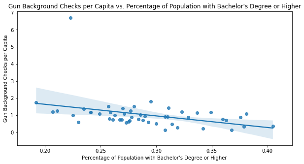

```python
#Plotting the relationship between gun background checks per capita and the percentage of the population with
#bachelor's degrees or higher
plt.figure(figsize=(10,5))
ax1 = sns.regplot(x='edu_percent',y='per_cap',data=gun_edu)
ax1.set(title = "Gun Background Checks per Capita vs. Percentage of Population with Bachelor's Degree or Higher")
ax1.set(ylabel = 'Gun Background Checks per Capita')
ax1.set(xlabel = "Percentage of Population with Bachelor's Degree or Higher");
```

```python
#Finding the correlation coeffiecient between the two variables
edu_corr = gun_edu[['per_cap','edu_percent']].corr().loc['edu_percent','per_cap']
edu_corr
```

```
-0.36774084377967653
```

**It can be seen here that there is a noticeable negative correlation between the percentage of the population with bachelor's degrees or higher and gun background checks per capita. States with a higher percentage of people with a college education tend to have lower gun background checks per capita according to the datasets.**

**Poverty**

> **Here I will be looking at the percentage of persons living in poverty in each state compared to the gun background checks per capita. Poverty is an important socioeconomic factor that could also have an effect on gun background checks per capita.**

*(I will be using the same methods as used above for education to create and plot the poverty dataframe in relation to gun background checks per capita.)*

```python
c_poverty = c.loc[:,['state','persons_in_poverty_percent']]
c_poverty.set_index('state',inplace=True)
```

```python
rows_to_change2 = c_poverty.iloc[np.r_[0:30,42:50]]
rows_to_change2.loc[:,'persons_in_poverty_percent'] = rows_to_change2.loc[:,'persons_in_poverty_percent'].str.rstrip('%').astype('float') / 100.0
```

```python
good_rows2 = c_poverty.loc['New Mexico':'Tennessee']
good_rows2 = good_rows2.astype(float)
```

```python
new_rows2 = rows_to_change2.append(good_rows2).sort_values('state')
```

```python
old_rows2 = c_poverty.iloc[:50]
c_poverty.drop(old_rows2.index,inplace=True)
```

```python
c_poverty = c_poverty.append(new_rows2)
```

```python
gun_poverty = gun_per_cap.merge(c_poverty,on='state',how='inner')
gun_poverty = gun_poverty.rename(columns={'persons_in_poverty_percent':'poverty_percent'})
gun_poverty.sort_values('poverty_percent',ascending=False,inplace=True)
gun_poverty
```

| state | gun_background_checks | pop_7_1_2016 | per_cap | poverty_percent |
| --- | --- | --- | --- | --- |
| Mississippi | 3576312 | 2988726 | 1.196601 | 0.208 |
| Louisiana | 4705057 | 4681666 | 1.004996 | 0.202 |
| New Mexico | 2076591 | 2081015 | 0.997874 | 0.198 |
| Kentucky | 29762434 | 4436974 | 6.707822 | 0.185 |
| West Virginia | 3208889 | 1831102 | 1.752436 | 0.179 |
| Arkansas | 3752633 | 2988248 | 1.255797 | 0.172 |
| Alabama | 6706079 | 4863300 | 1.378915 | 0.171 |
| Arizona | 4425714 | 6931071 | 0.638532 | 0.164 |
| Oklahoma | 4584454 | 3923561 | 1.168442 | 0.163 |
| Georgia | 7209942 | 10310371 | 0.699290 | 0.160 |
| Tennessee | 7311293 | 6651194 | 1.099245 | 0.158 |
| Texas | 19435186 | 27862596 | 0.697537 | 0.156 |
| North Carolina | 7777689 | 10146788 | 0.766517 | 0.154 |
| South Carolina | 4014432 | 4961119 | 0.809179 | 0.153 |
| Michigan | 7254279 | 9928300 | 0.730667 | 0.150 |
| Florida | 11695777 | 20612439 | 0.567414 | 0.147 |
| New York | 4643828 | 19745289 | 0.235187 | 0.147 |
| Ohio | 8462744 | 11614373 | 0.728644 | 0.146 |
| Idaho | 1968134 | 1683140 | 1.169323 | 0.144 |
| California | 19014063 | 39250017 | 0.484435 | 0.143 |
| Indiana | 7737172 | 6633053 | 1.166457 | 0.141 |
| Missouri | 6549018 | 6093000 | 1.074843 | 0.140 |
| Nevada | 1731797 | 2940058 | 0.589035 | 0.138 |
| South Dakota | 1215712 | 865454 | 1.404710 | 0.133 |
| Oregon | 3751061 | 4093465 | 0.916354 | 0.133 |
| Montana | 1884124 | 1042520 | 1.807279 | 0.133 |
| Illinois | 15471534 | 12801539 | 1.208568 | 0.130 |
| Pennsylvania | 13133876 | 12784227 | 1.027350 | 0.129 |
| Rhode Island | 288870 | 1056426 | 0.273441 | 0.128 |
| Maine | 1257457 | 1331479 | 0.944406 | 0.125 |
| Kansas | 2624669 | 2907289 | 0.902789 | 0.121 |
| Vermont | 484447 | 624594 | 0.775619 | 0.119 |
| Wisconsin | 5131725 | 5778708 | 0.888040 | 0.118 |
| Iowa | 2297156 | 3134693 | 0.732817 | 0.118 |
| Delaware | 491369 | 952065 | 0.516109 | 0.117 |
| Nebraska | 1136209 | 1907116 | 0.595773 | 0.114 |
| Washington | 6384517 | 7288000 | 0.876031 | 0.113 |
| Wyoming | 894306 | 585501 | 1.527420 | 0.113 |
| Virginia | 5878675 | 8411808 | 0.698860 | 0.110 |
| Colorado | 6058482 | 5540545 | 1.093481 | 0.110 |
| North Dakota | 947440 | 757952 | 1.250000 | 0.107 |
| Massachusetts | 2571321 | 6811779 | 0.377482 | 0.104 |
| New Jersey | 1145846 | 8944469 | 0.128107 | 0.104 |
| Utah | 4338273 | 3051217 | 1.421817 | 0.102 |
| Minnesota | 6279271 | 5519952 | 1.137559 | 0.099 |
| Alaska | 1137643 | 741894 | 1.533431 | 0.099 |
| Connecticut | 3168126 | 3576452 | 0.885829 | 0.098 |
| Maryland | 2035652 | 6016447 | 0.338348 | 0.097 |
| Hawaii | 197580 | 1428557 | 0.138307 | 0.093 |
| New Hampshire | 1583148 | 1334795 | 1.186061 | 0.073 |

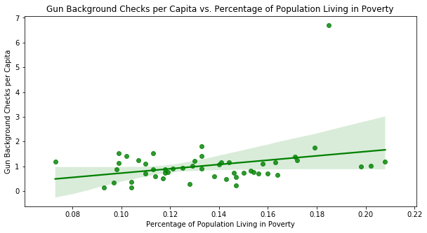

```python
plt.figure(figsize=(10,5))
ax2 = sns.regplot(x='poverty_percent',y='per_cap',data=gun_poverty,color='g')
ax2.set(title = 'Gun Background Checks per Capita vs. Percentage of Population Living in Poverty')
ax2.set(ylabel = 'Gun Background Checks per Capita')
ax2.set(xlabel = "Percentage of Population Living in Poverty");
```

```python
poverty_corr = gun_poverty[['per_cap','poverty_percent']].corr().loc['poverty_percent','per_cap']
poverty_corr
```

```
0.2894510037483308
```

**It can be seen here that there is some correlation between the percentage of population living in poverty and gun background checks per capita. There is a positive relationship between the two meaning that states with higher levels of poverty tend to have more gun background checks per capita. This could be for many reasons, such as people seeking guns for protection in impoverished areas or for criminal activity, since statistics do show that criminals often acquire guns through legal means.**

**Median Household Income**

> **Here I will be looking at the median household income in relation to gun background checks per capita. This factor should be similar to poverty.**

*(I will be using the same methods as used above for education to create and plot the poverty dataframe in relation to gun background checks per capita.)*

```python
c_income = c.loc[:,['state','median_household_income_in_2015_dollars_2011_2015']]
c_income.set_index('state',inplace=True)
```

```python
rows_to_change3 = c_income.iloc[np.r_[0:30,42:50]]
rows_to_change3.loc[:,'median_household_income_in_2015_dollars_2011_2015'] = rows_to_change3.loc[:,'median_household_income_in_2015_dollars_2011_2015'].str.replace('$','').str.replace(',','').astype('float')
```

```python
good_rows3 = c_income.loc['New Mexico':'Tennessee']
good_rows3 = good_rows3.astype('float')
```

```python
new_rows3 = rows_to_change3.append(good_rows3).sort_values('state')
```

```python
old_rows3 = c_income.iloc[:50]
c_income = c_income.drop(old_rows3.index)
```

```python
c_income = c_income.append(new_rows3)
```

```python
gun_income = gun_per_cap.merge(c_income,on='state',how='inner')
gun_income = gun_income.rename(columns={'median_household_income_in_2015_dollars_2011_2015':'median_household_income'})
gun_income.sort_values('median_household_income',ascending=False)
```

| state | gun_background_checks | pop_7_1_2016 | per_cap | median_household_income |
| --- | --- | --- | --- | --- |
| Maryland | 2035652 | 6016447 | 0.338348 | 74551.0 |
| Alaska | 1137643 | 741894 | 1.533431 | 72515.0 |
| New Jersey | 1145846 | 8944469 | 0.128107 | 72093.0 |
| Connecticut | 3168126 | 3576452 | 0.885829 | 70331.0 |
| Hawaii | 197580 | 1428557 | 0.138307 | 69515.0 |
| Massachusetts | 2571321 | 6811779 | 0.377482 | 68563.0 |
| New Hampshire | 1583148 | 1334795 | 1.186061 | 66779.0 |
| Virginia | 5878675 | 8411808 | 0.698860 | 65015.0 |
| California | 19014063 | 39250017 | 0.484435 | 61818.0 |
| Minnesota | 6279271 | 5519952 | 1.137559 | 61492.0 |
| Washington | 6384517 | 7288000 | 0.876031 | 61062.0 |
| Utah | 4338273 | 3051217 | 1.421817 | 60727.0 |
| Colorado | 6058482 | 5540545 | 1.093481 | 60629.0 |
| Delaware | 491369 | 952065 | 0.516109 | 60509.0 |
| New York | 4643828 | 19745289 | 0.235187 | 59269.0 |
| Wyoming | 894306 | 585501 | 1.527420 | 58840.0 |
| Illinois | 15471534 | 12801539 | 1.208568 | 57574.0 |
| North Dakota | 947440 | 757952 | 1.250000 | 57181.0 |
| Rhode Island | 288870 | 1056426 | 0.273441 | 56852.0 |
| Vermont | 484447 | 624594 | 0.775619 | 55176.0 |
| Pennsylvania | 13133876 | 12784227 | 1.027350 | 53599.0 |
| Wisconsin | 5131725 | 5778708 | 0.888040 | 53357.0 |
| Texas | 19435186 | 27862596 | 0.697537 | 53207.0 |
| Iowa | 2297156 | 3134693 | 0.732817 | 53183.0 |
| Nebraska | 1136209 | 1907116 | 0.595773 | 52997.0 |
| Kansas | 2624669 | 2907289 | 0.902789 | 52205.0 |
| Nevada | 1731797 | 2940058 | 0.589035 | 51847.0 |
| Oregon | 3751061 | 4093465 | 0.916354 | 51243.0 |
| South Dakota | 1215712 | 865454 | 1.404710 | 50957.0 |
| Arizona | 4425714 | 6931071 | 0.638532 | 50255.0 |
| Georgia | 7209942 | 10310371 | 0.699290 | 49620.0 |
| Michigan | 7254279 | 9928300 | 0.730667 | 49576.0 |
| Ohio | 8462744 | 11614373 | 0.728644 | 49429.0 |
| Maine | 1257457 | 1331479 | 0.944406 | 49331.0 |
| Indiana | 7737172 | 6633053 | 1.166457 | 49255.0 |
| Missouri | 6549018 | 6093000 | 1.074843 | 48173.0 |
| Idaho | 1968134 | 1683140 | 1.169323 | 47583.0 |
| Florida | 11695777 | 20612439 | 0.567414 | 47507.0 |
| Montana | 1884124 | 1042520 | 1.807279 | 47169.0 |
| Oklahoma | 4584454 | 3923561 | 1.168442 | 46879.0 |
| North Carolina | 7777689 | 10146788 | 0.766517 | 46868.0 |
| South Carolina | 4014432 | 4961119 | 0.809179 | 45483.0 |
| Tennessee | 7311293 | 6651194 | 1.099245 | 45219.0 |
| Louisiana | 4705057 | 4681666 | 1.004996 | 45047.0 |
| New Mexico | 2076591 | 2081015 | 0.997874 | 44963.0 |
| Kentucky | 29762434 | 4436974 | 6.707822 | 43740.0 |
| Alabama | 6706079 | 4863300 | 1.378915 | 43623.0 |
| West Virginia | 3208889 | 1831102 | 1.752436 | 41751.0 |
| Arkansas | 3752633 | 2988248 | 1.255797 | 41371.0 |
| Mississippi | 3576312 | 2988726 | 1.196601 | 39665.0 |

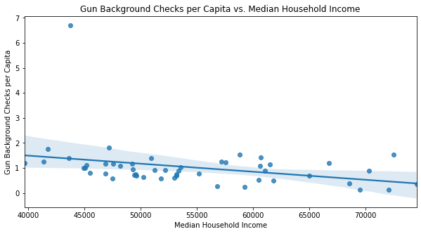

```python
plt.figure(figsize=(10,5))
ax3 = sns.regplot(x='median_household_income',y='per_cap',data=gun_income)
ax3.set(title = 'Gun Background Checks per Capita vs. Median Household Income')
ax3.set(ylabel = 'Gun Background Checks per Capita')
ax3.set(xlabel = "Median Household Income");
```

```python
income_corr = gun_income[['per_cap','median_household_income']].corr().loc['median_household_income','per_cap']
income_corr
```

```
-0.3169255730096412
```

**The relationship between median household income and gun background checks per capita is just about that of poverty mirrored, as the higher the median household income, the lower the gun background checks per capita. This could be due to the fact that with greater income, people can afford to live in safer neighborhoods and people are less compelled to commit crimes to live sustainably.**

**Aging Population**

> **Here I will be looking at the percentage of the population over the age of 65 in relation to gun background checks per capita. Arguments tend to link older age with having more conservative views. So, it will be interesting to see what correlation these two variables have.**

*(I will be using the same methods as used above for education to create and plot the poverty dataframe in relation to gun background checks per capita.)*

```python
c_aging = c.loc[:,['state','persons_65_years_and_over_percent__july_1_2016__v2016']]
c_aging.set_index('state',inplace=True)
```

```python
rows_to_change4 = c_aging.iloc[np.r_[0:30,42:50]]
rows_to_change4.loc[:,'persons_65_years_and_over_percent__july_1_2016__v2016'] = rows_to_change4.loc[:,'persons_65_years_and_over_percent__july_1_2016__v2016'].str.rstrip('%').astype('float') / 100.0
```

```python
good_rows4 = c_aging.loc['New Mexico':'Tennessee']
good_rows4 = good_rows4.astype(float)
```

```python
new_rows4 = rows_to_change4.append(good_rows4).sort_values('state')
```

```python
old_rows4 = c_aging.iloc[:50]
c_aging.drop(old_rows4.index,inplace=True)
```

```python
c_aging = c_aging.append(new_rows4)
```

```python
gun_aging = gun_per_cap.merge(c_aging,on='state',how='inner')
gun_aging = gun_aging.rename(columns={'persons_65_years_and_over_percent__july_1_2016__v2016':'over_65'})
gun_aging.sort_values('over_65',ascending=False,inplace=True)
gun_aging
```

| state | gun_background_checks | pop_7_1_2016 | per_cap | over_65 |
| --- | --- | --- | --- | --- |
| Florida | 11695777 | 20612439 | 0.567414 | 0.199 |
| Maine | 1257457 | 1331479 | 0.944406 | 0.194 |
| West Virginia | 3208889 | 1831102 | 1.752436 | 0.188 |
| Vermont | 484447 | 624594 | 0.775619 | 0.181 |
| Montana | 1884124 | 1042520 | 1.807279 | 0.177 |
| Delaware | 491369 | 952065 | 0.516109 | 0.175 |
| Pennsylvania | 13133876 | 12784227 | 1.027350 | 0.174 |
| Hawaii | 197580 | 1428557 | 0.138307 | 0.171 |
| New Hampshire | 1583148 | 1334795 | 1.186061 | 0.170 |
| Arizona | 4425714 | 6931071 | 0.638532 | 0.169 |
| Oregon | 3751061 | 4093465 | 0.916354 | 0.168 |
| South Carolina | 4014432 | 4961119 | 0.809179 | 0.167 |
| Rhode Island | 288870 | 1056426 | 0.273441 | 0.165 |
| New Mexico | 2076591 | 2081015 | 0.997874 | 0.165 |
| Iowa | 2297156 | 3134693 | 0.732817 | 0.164 |
| Arkansas | 3752633 | 2988248 | 1.255797 | 0.163 |
| Michigan | 7254279 | 9928300 | 0.730667 | 0.162 |
| Ohio | 8462744 | 11614373 | 0.728644 | 0.162 |
| Wisconsin | 5131725 | 5778708 | 0.888040 | 0.161 |
| Connecticut | 3168126 | 3576452 | 0.885829 | 0.161 |
| Missouri | 6549018 | 6093000 | 1.074843 | 0.161 |
| Alabama | 6706079 | 4863300 | 1.378915 | 0.161 |
| South Dakota | 1215712 | 865454 | 1.404710 | 0.160 |
| Massachusetts | 2571321 | 6811779 | 0.377482 | 0.158 |
| Tennessee | 7311293 | 6651194 | 1.099245 | 0.157 |
| Kentucky | 29762434 | 4436974 | 6.707822 | 0.156 |
| North Carolina | 7777689 | 10146788 | 0.766517 | 0.155 |
| New York | 4643828 | 19745289 | 0.235187 | 0.154 |
| New Jersey | 1145846 | 8944469 | 0.128107 | 0.153 |
| Idaho | 1968134 | 1683140 | 1.169323 | 0.151 |
| Minnesota | 6279271 | 5519952 | 1.137559 | 0.151 |
| Mississippi | 3576312 | 2988726 | 1.196601 | 0.151 |
| Nebraska | 1136209 | 1907116 | 0.595773 | 0.150 |
| Wyoming | 894306 | 585501 | 1.527420 | 0.150 |
| Nevada | 1731797 | 2940058 | 0.589035 | 0.150 |
| Kansas | 2624669 | 2907289 | 0.902789 | 0.150 |
| Oklahoma | 4584454 | 3923561 | 1.168442 | 0.150 |
| Indiana | 7737172 | 6633053 | 1.166457 | 0.149 |
| Washington | 6384517 | 7288000 | 0.876031 | 0.148 |
| Virginia | 5878675 | 8411808 | 0.698860 | 0.146 |
| Illinois | 15471534 | 12801539 | 1.208568 | 0.146 |
| Maryland | 2035652 | 6016447 | 0.338348 | 0.146 |
| North Dakota | 947440 | 757952 | 1.250000 | 0.145 |
| Louisiana | 4705057 | 4681666 | 1.004996 | 0.144 |
| California | 19014063 | 39250017 | 0.484435 | 0.136 |
| Colorado | 6058482 | 5540545 | 1.093481 | 0.134 |
| Georgia | 7209942 | 10310371 | 0.699290 | 0.131 |
| Texas | 19435186 | 27862596 | 0.697537 | 0.120 |
| Utah | 4338273 | 3051217 | 1.421817 | 0.105 |
| Alaska | 1137643 | 741894 | 1.533431 | 0.104 |

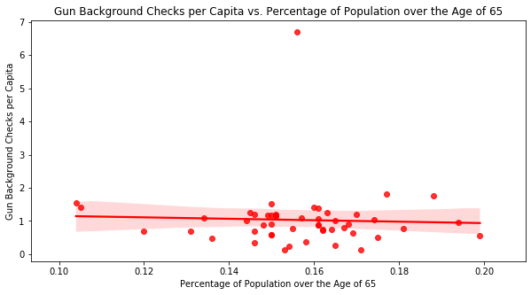

```python
plt.figure(figsize=(10,5))
ax4 = sns.regplot(x='over_65',y='per_cap',data=gun_aging,color='r')
ax4.set(title = 'Gun Background Checks per Capita vs. Percentage of Population over the Age of 65')
ax4.set(ylabel = 'Gun Background Checks per Capita')
ax4.set(xlabel = "Percentage of Population over the Age of 65");
```

```python
aging_corr = gun_aging[['per_cap','over_65']].corr().loc['over_65','per_cap']
aging_corr
```

```
-0.04384679229189966
```

**The plot above shows the relationship between the percentage of people over the age of 65 and gun background checks per capita. It is generally accepted in politics that older age is often connected to more conservative views, one of which is the protection of anything impeding upon second amendment rights in the U.S.. Yet, this plot and correlation coefficient show hardly any correlation. This could be due to the fact that most states are becoming equal in their percentage of person over 65 due to modern medicine, so that both majority liberal and conservative states both have similar percentages of people over 65, which can also be seen in the plot, in that a lot of the points are located mostly in the center.**

**Young Population**

> **Here I will be looking at the percentage of the population under the age of 18 in relation to gun background checks per capita. While persons under the age of 18 aren't able to purchase guns, this factor is still an indicator of states that have a younger population. Arguments tend to link younger age with having more liberal views. So, it will be interesting to see what correlation these two variables have in comparison to that of the aging population.**

*(I will be using the same methods as used above for education to create and plot the poverty dataframe in relation to gun background checks per capita.)*

```python
c_young = c.loc[:,['state','persons_under_18_years_percent_july_1_2016__v2016']]
c_young.set_index('state',inplace=True)
```

```python
rows_to_change5 = c_young.iloc[np.r_[0:30,42:50]]
rows_to_change5.loc[:,'persons_under_18_years_percent_july_1_2016__v2016'] = rows_to_change5.loc[:,'persons_under_18_years_percent_july_1_2016__v2016'].str.rstrip('%').astype('float') / 100.0
```

```python
good_rows5 = c_young.loc['New Mexico':'Tennessee']
good_rows5 = good_rows5.astype(float)
```

```python
new_rows5 = rows_to_change5.append(good_rows5).sort_values('state')
```

```python
old_rows5 = c_young.iloc[:50]
c_young.drop(old_rows5.index,inplace=True)
```

```python
c_young = c_young.append(new_rows5)
```

```python
gun_young = gun_per_cap.merge(c_young,on='state',how='inner')
gun_young = gun_young.rename(columns={'persons_under_18_years_percent_july_1_2016__v2016':'under_18'})
gun_young.sort_values('under_18',ascending=False,inplace=True)
gun_young
```

| state | gun_background_checks | pop_7_1_2016 | per_cap | under_18 |
| --- | --- | --- | --- | --- |
| Utah | 4338273 | 3051217 | 1.421817 | 0.302 |
| Texas | 19435186 | 27862596 | 0.697537 | 0.262 |
| Idaho | 1968134 | 1683140 | 1.169323 | 0.260 |
| Alaska | 1137643 | 741894 | 1.533431 | 0.252 |
| Nebraska | 1136209 | 1907116 | 0.595773 | 0.248 |
| Kansas | 2624669 | 2907289 | 0.902789 | 0.246 |
| South Dakota | 1215712 | 865454 | 1.404710 | 0.246 |
| Oklahoma | 4584454 | 3923561 | 1.168442 | 0.245 |
| Georgia | 7209942 | 10310371 | 0.699290 | 0.244 |
| Mississippi | 3576312 | 2988726 | 1.196601 | 0.241 |
| Indiana | 7737172 | 6633053 | 1.166457 | 0.238 |
| Louisiana | 4705057 | 4681666 | 1.004996 | 0.238 |
| Wyoming | 894306 | 585501 | 1.527420 | 0.237 |
| Arkansas | 3752633 | 2988248 | 1.255797 | 0.236 |
| New Mexico | 2076591 | 2081015 | 0.997874 | 0.236 |
| Arizona | 4425714 | 6931071 | 0.638532 | 0.235 |
| North Dakota | 947440 | 757952 | 1.250000 | 0.233 |
| Minnesota | 6279271 | 5519952 | 1.137559 | 0.233 |
| Iowa | 2297156 | 3134693 | 0.732817 | 0.233 |
| California | 19014063 | 39250017 | 0.484435 | 0.232 |
| Nevada | 1731797 | 2940058 | 0.589035 | 0.230 |
| Illinois | 15471534 | 12801539 | 1.208568 | 0.229 |
| Kentucky | 29762434 | 4436974 | 6.707822 | 0.228 |
| Colorado | 6058482 | 5540545 | 1.093481 | 0.228 |
| Missouri | 6549018 | 6093000 | 1.074843 | 0.228 |
| North Carolina | 7777689 | 10146788 | 0.766517 | 0.227 |
| Alabama | 6706079 | 4863300 | 1.378915 | 0.226 |
| Tennessee | 7311293 | 6651194 | 1.099245 | 0.226 |
| Ohio | 8462744 | 11614373 | 0.728644 | 0.225 |
| Maryland | 2035652 | 6016447 | 0.338348 | 0.224 |
| Washington | 6384517 | 7288000 | 0.876031 | 0.224 |
| Wisconsin | 5131725 | 5778708 | 0.888040 | 0.223 |
| Virginia | 5878675 | 8411808 | 0.698860 | 0.222 |
| New Jersey | 1145846 | 8944469 | 0.128107 | 0.222 |
| Michigan | 7254279 | 9928300 | 0.730667 | 0.221 |
| South Carolina | 4014432 | 4961119 | 0.809179 | 0.221 |
| Montana | 1884124 | 1042520 | 1.807279 | 0.218 |
| Hawaii | 197580 | 1428557 | 0.138307 | 0.216 |
| Delaware | 491369 | 952065 | 0.516109 | 0.215 |
| Oregon | 3751061 | 4093465 | 0.916354 | 0.212 |
| New York | 4643828 | 19745289 | 0.235187 | 0.212 |
| Connecticut | 3168126 | 3576452 | 0.885829 | 0.211 |
| Pennsylvania | 13133876 | 12784227 | 1.027350 | 0.209 |
| West Virginia | 3208889 | 1831102 | 1.752436 | 0.205 |
| Massachusetts | 2571321 | 6811779 | 0.377482 | 0.202 |
| Florida | 11695777 | 20612439 | 0.567414 | 0.201 |
| Rhode Island | 288870 | 1056426 | 0.273441 | 0.197 |
| New Hampshire | 1583148 | 1334795 | 1.186061 | 0.195 |
| Maine | 1257457 | 1331479 | 0.944406 | 0.191 |
| Vermont | 484447 | 624594 | 0.775619 | 0.190 |

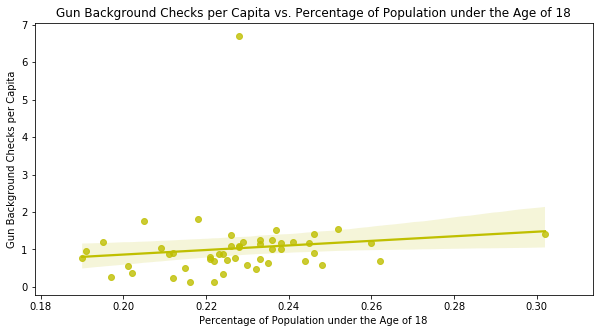

```python
plt.figure(figsize=(10,5))
ax5 = sns.regplot(x='under_18',y='per_cap',data=gun_young,color='y')
ax5.set(title = 'Gun Background Checks per Capita vs. Percentage of Population under the Age of 18')
ax5.set(ylabel = 'Gun Background Checks per Capita')
ax5.set(xlabel = "Percentage of Population under the Age of 18");
```

```python
young_corr = gun_young[['per_cap','under_18']].corr().loc['under_18','per_cap']
young_corr
```

```
0.13289773065040206
```

**This plot shows the relationship between the percentage of the population under the age of 18 and the gun background checks per capita. Surprisingly, it is the opposite of what was assumed in the over 65 plot, in that there is a slight positive relationship between the greater percentage of persons under 18 and gun background checks per capita. This could also be just because, states are closer in these percentages than I thought, and that states have similar percentages in their percentage of persons under 18.**

```python
correlations = {'Factor':['Education','Poverty','Median Household Income','Aging Population','Young Population'],'Correlation Coefficient':[edu_corr,poverty_corr,income_corr,aging_corr,young_corr]}
socio_corr = pd.DataFrame(correlations,columns=['Factor','Correlation Coefficient'])
socio_corr = socio_corr.sort_values('Correlation Coefficient',ascending=False).reset_index(drop=True)
socio_corr
```

|  | Factor | Correlation Coefficient |
| --- | --- | --- |
| 0 | Poverty | 0.289451 |
| 1 | Young Population | 0.132898 |
| 2 | Aging Population | -0.043847 |
| 3 | Median Household Income | -0.316926 |
| 4 | Education | -0.367741 |

### What do the trends of gun-related background checks look like for the states with the highest high gun-related backgrounds per capita?

```python
#Top 5 states for gun background checks per capita
gun_per_cap.head()
```

| state | gun_background_checks | pop_7_1_2016 | per_cap |
| --- | --- | --- | --- |
| Kentucky | 29762434 | 4436974 | 6.707822 |
| Montana | 1884124 | 1042520 | 1.807279 |
| West Virginia | 3208889 | 1831102 | 1.752436 |
| Alaska | 1137643 | 741894 | 1.533431 |
| Wyoming | 894306 | 585501 | 1.527420 |

```python
#Creating a datframe of the states, month, and the total number of gun background checks and setting month as the
#index in order to analyze it per state
gun_trend_state = gun_data[['state','month','totals']]
gun_trend_state = gun_trend_state.reset_index(drop=True)
gun_trend_state = gun_trend_state.set_index('month')
```

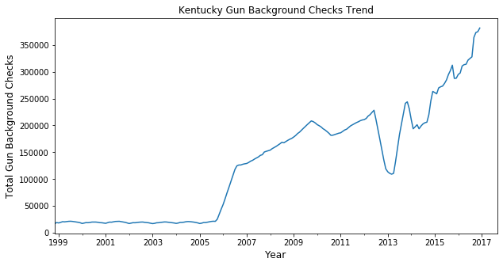

```python
#Plotting the rolling average of the total gun backgrounds checks from 1998 to 2017 for Kentucky
gun_trend_kentucky = gun_trend_state.query('state == "Kentucky"')
gun_trend_kentucky.rolling(window=10).mean().plot(legend=None,figsize=(10,5))
plt.title('Kentucky Gun Background Checks Trend')
plt.xlabel('Year',fontsize=12)
plt.ylabel('Total Gun Background Checks',fontsize=12);
```

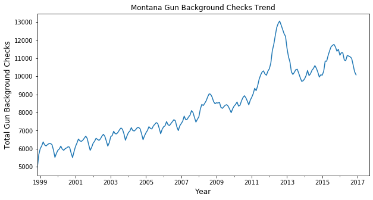

```python
#Plotting the rolling average of the total gun backgrounds checks from 1998 to 2017 for Montana
gun_trend_montana = gun_trend_state.query('state == "Montana"')
gun_trend_montana.rolling(window=10).mean().plot(legend=None,figsize=(10,5))
plt.title('Montana Gun Background Checks Trend')
plt.xlabel('Year',fontsize=12)
plt.ylabel('Total Gun Background Checks',fontsize=12);
```

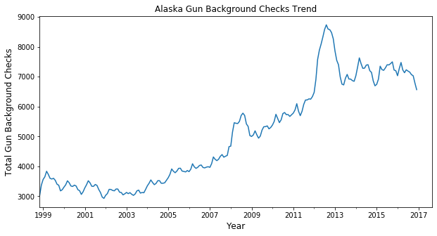

```python
#Plotting the rolling average of the total gun backgrounds checks from 1998 to 2017 for Alaska
gun_trend_alaska = gun_trend_state.query('state == "Alaska"')
gun_trend_alaska.rolling(window=10).mean().plot(legend=None,figsize=(10,5))
plt.title('Alaska Gun Background Checks Trend')
plt.xlabel('Year',fontsize=12)
plt.ylabel('Total Gun Background Checks',fontsize=12);
```

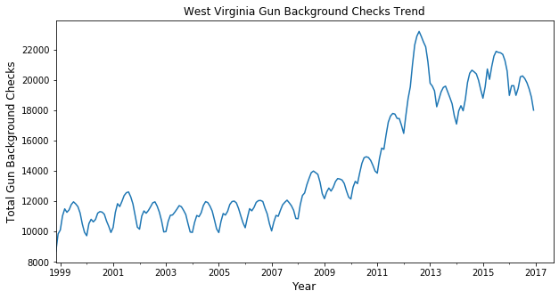

```python
#Plotting the rolling average of the total gun backgrounds checks from 1998 to 2017 for West Virginia
gun_trend_west_virginia = gun_trend_state.query('state == "West Virginia"')
gun_trend_west_virginia.rolling(window=10).mean().plot(legend=None,figsize=(10,5))
plt.title('West Virginia Gun Background Checks Trend')
plt.xlabel('Year',fontsize=12)
plt.ylabel('Total Gun Background Checks',fontsize=12);
```

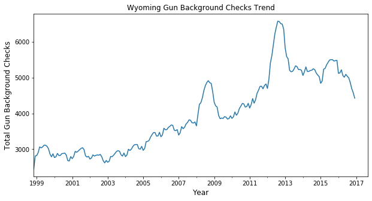

```python
#Plotting the rolling average of the total gun backgrounds checks from 1998 to 2017 for Wyoming
gun_trend_wyoming = gun_trend_state.query('state == "Wyoming"')
gun_trend_wyoming.rolling(window=10).mean().plot(legend=None,figsize=(10,5))
plt.title('Wyoming Gun Background Checks Trend')
plt.xlabel('Year',fontsize=12)
plt.ylabel('Total Gun Background Checks',fontsize=12);
```

**A rise in the total number of background checks can be seen across all 5 of the top gun background checks per capita states. This rise really begins to pick up in the mid-2000's. While Kentucky goes from a lower number of gun background checks and spikes suddenly around 2006, the other four states show more of a gradual. There are also two spikes that can be seen in most plots around 2008 and 2012, which coincide with President Obama's election and subsequent re-election. Greater gun sales occurred during these times due to conservatives' fears that the more liberal President Obama would bring change to their second amendment rights. In all plots, but Kentucky, there is also a drop off in background checks since 2016. This is possibly due to the election of Donald Trump, which eased the fears of conservatives thus slowing down the purchase of guns.**

**Supporting articles:**

- https://www.worldfinance.com/markets/whats-really-causing-the-slump-in-us-gun-sales

### Which of these top 5 states has shown the highest average percentage change in gun-related background checks over the time frame available in the dataset?

```python
pct_chg = {'State':['Kentucky','Montana','Alaska','West Virginia','Wyoming'],'Percent Change':[gun_trend_kentucky['totals'].pct_change().mean()*100,gun_trend_montana['totals'].pct_change().mean()*100,gun_trend_alaska['totals'].pct_change().mean()*100,gun_trend_west_virginia['totals'].pct_change().mean()*100,gun_trend_wyoming['totals'].pct_change().mean()*100]}
gun_trend_pct_chg = pd.DataFrame(pct_chg,columns=['State','Percent Change'])
gun_trend_pct_chg.sort_values('Percent Change',ascending=False).reset_index(drop=True)
```

|  | State | Percent Change |
| --- | --- | --- |
| 0 | Kentucky | 7.577448 |
| 1 | Alaska | 2.716066 |
| 2 | West Virginia | 2.030265 |
| 3 | Montana | 1.747208 |
| 4 | Wyoming | 1.641120 |

**After viewing the analysis above, it doesn't come as a surprise that Kentucky shows the highest average percent change over the time frame available in the data set. In the Kentucky plot above, it can be seen that Kentucky experienced a sudden spike in gun background checks, as opposed to the more gradual increase of the other states.**

### What do the overall trends look like for concealed-carry permits, handguns, and long guns?

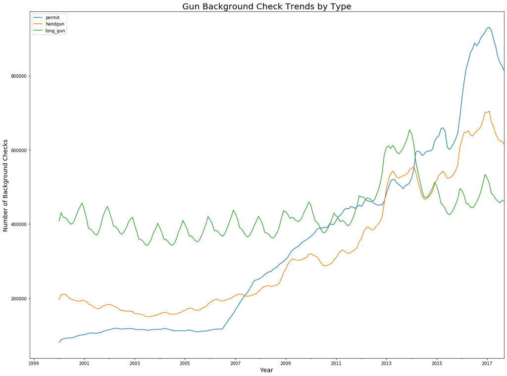

```python
check_trend = gun_data[['month','permit','handgun','long_gun','prepawn_handgun','private_sale_handgun','private_sale_long_gun']].groupby('month').aggregate({'permit':'sum','handgun':'sum','long_gun':'sum','prepawn_handgun':'sum','private_sale_handgun':'sum','private_sale_long_gun':'sum'})
check_trend['permit'].rolling(window=15).mean().plot()
check_trend['handgun'].rolling(window=15).mean().plot()
check_trend['long_gun'].rolling(window=15).mean().plot(figsize=(20,15))
plt.title('Gun Background Check Trends by Type',fontsize=20)
plt.xlabel('Year',fontsize=14)
plt.ylabel('Number of Background Checks',fontsize=14)
plt.legend();
```

**This plot shows the rolling averages of concealed-carry permit, handgun sales, and long gun sales background checks over the time frame of the dataset. Here you can see that permits have show a very large increase over the two decades provided by the dataset. Handgun sales were also increasing at a high rate over the time frame, but long gun sales were overall rather level up until about 2012, where a spike can be seen. This spike then levels off and drops just a couple years later. This could possibly be due to politics surrounding the ownership of semi-automatic and assault rifles in recent years. The number of background checks for all three types are showing drops since about 2016 further supporting the drop in gun sales since Donald Trump was elected the president of the U.S.**

## Conclusions

```python
gun_trend_pct_chg
```

|  | State | Percent Change |
| --- | --- | --- |
| 0 | Kentucky | 7.577448 |
| 1 | Montana | 1.747208 |
| 2 | Alaska | 2.716066 |
| 3 | West Virginia | 2.030265 |
| 4 | Wyoming | 1.641120 |

```python
socio_corr
```

|  | Factor | Correlation Coefficient |
| --- | --- | --- |
| 0 | Poverty | 0.289451 |
| 1 | Young Population | 0.132898 |
| 2 | Aging Population | -0.043847 |
| 3 | Median Household Income | -0.316926 |
| 4 | Education | -0.367741 |

**Although the findings in this report are tentative due to the limits of the dataset and information available, overall, it can be seen that gun background checks have increased greatly over the past two decades due to greater gun sales. This trend can be seen across all of the top 5 states for gun background checks per capita, especially in Kentucky. It was found that Kentucky has seen a surge in gun sales in the past two decades and it leads the country in gun background checks per capita and in total gun background checks, even despite its smaller population in comparison to larger states. Concealed-carry permit and handgun background checks have seen a large surge in the past two decades, yet long gun sales have stayed rather level but have seen a drop since 2016 due possibly to politics and the emphasis on handguns and concealed-carry permits, which are mostly associated with self-defense. This is often cited as the reason for gun purchases.**

**In analyzing which socioeconomic factors contribute the most to states having more gun-related background checks due to greater gun sales, I investigated the relationships between gun background checks per capita and education, poverty, median household income, and the percentage of people over 65 and under 18. The three factors that showed a decent correlation to higher gun background checks were education (the percentage of persons with a college education), the percentage of persons living in poverty, and the median household income, which of course was very similar to the poverty percentage factor. The strongest among them all, as can be seen in the dataframe above, is education, which has a relatively strong negative correlation to gun background checks. This, although only tentatively due to the amount of data and information available, that states with a percentage of college educated people tend to have lower gun background checks per capita. Impoverished states contrarily tend to show a higher number of gun background checks and the percentage of people over the age of 65 and the percentage of people under the age of 18 don't seem to have much correlation. While gun sales and gun laws are always a part of political debate, gun sales are still ever-increasing, although a drop can be seen to some degree around 2016. Possibly, sales are beginning to level off or even decrease. With another election coming up in 2020, there could although be another change to this trend very soon, whether that is a drop or increase depends on many factors.**

**Websites Used for Coding Support:**

- https://pypi.org/project/matplotlib/
- https://pandas.pydata.org/
- https://www.w3schools.com/python/numpy_intro.asp
- https://seaborn.pydata.org/tutorial/aesthetics.html
- https://stackoverflow.com/questions/40095712/when-to-applypd-to-numeric-and-when-to-astypenp-float64-in-python